# Data Analyst Skills Test (Health Manager Level 2)

Phillip Hungerford

24/08/2021

# 1. Analysing Data

Please prepare code in R preferably to answer the following questions:

You will need to source data files (sim_av_patient.csv, sim_av_tumour.csv and other metadata files) from the UK synthetic cancer registry data (Simulacrum*) from (https://healthdatainsight.org.uk/project/the-simulacrum/).

1. What is the sex distribution of patients?
2. Prepare a dataset with all lung cancer patients (SITE_ICD10_O2_3CHAR= C34) and their cause of deaths.
3. Calculate the mean survival time in days for the lung cancer patients who were diagnosed in 2013.

## Dataset details

The Simulacrum is a dataset that contains artificial patient-like cancer data to help researchers gain insights.

Simulacrum contains 2013 – 2017 diagnoses and treatment follow up to March 2018.

First we download the data and check it against the data dictionary. The Cancer Outcomes & Services Dataset (COSD) is comprised of patient level data (sim_av_patient) and tumour level data (sim_av_tumour). These two tables are linked by the patient IDs (PATIENTID).

Based on this information, we will download the data and check it against the data dictionary.

```r
##############################################################################
# Prepare data
#=============================================================================
# Load patient level data with death information
sim_av_patient <- read.csv("simulacrum_release_v1.2.0.2017/data/sim_av_patient.csv", na.strings = c("", " "))

# load tumour level data with patient ID
sim_av_tumour <- read.csv("simulacrum_release_v1.2.0.2017/data/sim_av_tumour.csv", na.strings = c("", " "))

# inspect
head(sim_av_patient)
```

```
##   PATIENTID SEX LINKNUMBER ETHNICITY DEATHCAUSECODE_1A DEATHCAUSECODE_1B
## 1  10000001   1  810000001         Z              <NA>              <NA>
## 2  10000002   1  810000002         A              I259              <NA>
## 3  10000003   1  810000003         Z              <NA>              <NA>
## 4  10000004   2  810000004         A              <NA>              <NA>
## 5  10000005   1  810000005         A              <NA>              <NA>
## 6  10000006   2  810000006      <NA>              <NA>              <NA>
##   DEATHCAUSECODE_1C DEATHCAUSECODE_2 DEATHCAUSECODE_UNDERLYING
## 1              <NA>             <NA>                      <NA>
## 2              <NA>             I509                      I259
## 3              <NA>             <NA>                      <NA>
## 4              <NA>             <NA>                      <NA>
## 5              <NA>             <NA>                      <NA>
## 6              <NA>             <NA>                      <NA>
##   DEATHLOCATIONCODE NEWVITALSTATUS VITALSTATUSDATE
## 1              <NA>              A      2019-02-08
## 2                 4              A      2019-02-08
## 3              <NA>              A      2019-02-08
## 4              <NA>              D      2018-01-06
## 5              <NA>              A      2019-02-06
## 6              <NA>              A      2019-02-08
```

```r
head(sim_av_tumour)
```

```
##   TUMOURID PATIENTID DIAGNOSISDATEBEST SITE_ICD10_O2 SITE_ICD10_O2_3CHAR
## 1 10000001  10000001        2017-04-24          C447                 C44
## 2 10000002  10000002        2016-10-18          C449                 C44
## 3 10000003  10000003        2017-01-13          C447                 C44
## 4 10000004  10000004        2015-10-28          C449                 C44
## 5 10000005  10000005        2017-10-03          C449                 C44
## 6 10000006  10000006        2015-06-04          C440                 C44
##   MORPH_ICD10_O2 BEHAVIOUR_ICD10_O2 T_BEST N_BEST M_BEST STAGE_BEST
## 1           8070                  3      1   <NA>   <NA>          ?
## 2           8090                  3   <NA>   <NA>   <NA>          1
## 3           8070                  3   <NA>   <NA>   <NA>          ?
## 4           8090                  3   <NA>   <NA>   <NA>          ?
## 5           8090                  3   <NA>   <NA>   <NA>          ?
## 6           8090                  3   <NA>   <NA>   <NA>          ?
##   STAGE_BEST_SYSTEM GRADE AGE SEX CREG_CODE LINKNUMBER SCREENINGSTATUSFULL_CODE
```

[output cut: 34 more lines]

```r
# check columns match with data dictionary? Yes
```

Quickly check for missing values

```r
# check missing for key variables
na_count <-sapply(sim_av_patient, function(y) sum(length(which(is.na(y)))))
na_count <- data.frame(na_count)
print(na_count)
```

```
##                           na_count
## PATIENTID                        0
## SEX                              0
## LINKNUMBER                       0
## ETHNICITY                   171927
## DEATHCAUSECODE_1A          1552472
## DEATHCAUSECODE_1B          2008012
## DEATHCAUSECODE_1C          2163960
## DEATHCAUSECODE_2           1905369
## DEATHCAUSECODE_UNDERLYING  1552550
## DEATHLOCATIONCODE          1553407
## NEWVITALSTATUS                   3
## VITALSTATUSDATE                  3
```

```r
# check missing for key variables
na_count <-sapply(sim_av_tumour, function(y) sum(length(which(is.na(y)))))
na_count <- data.frame(na_count)
print(na_count)
```

```
##                          na_count
## TUMOURID                        0
## PATIENTID                       0
## DIAGNOSISDATEBEST               0
## SITE_ICD10_O2                1030
## SITE_ICD10_O2_3CHAR           876
## MORPH_ICD10_O2               1043
## BEHAVIOUR_ICD10_O2            584
## T_BEST                    1248221
## N_BEST                    1421422
## M_BEST                    1433395
## STAGE_BEST                    357
## STAGE_BEST_SYSTEM         1151693
## GRADE                      110981
## AGE                             0
## SEX                             0
## CREG_CODE                       0
## LINKNUMBER                      0
## SCREENINGSTATUSFULL_CODE  2150325
## ER_STATUS                 2161838
## ER_SCORE                  2313145
## PR_STATUS                 2237155
## PR_SCORE                  2338988
## HER2_STATUS               2186417
## CANCERCAREPLANINTENT      1606433
## PERFORMANCESTATUS         1662174
## CNS                       1983846
## ACE27                     2152051
## GLEASON_PRIMARY           2207704
## GLEASON_SECONDARY         2207770
## GLEASON_TERTIARY          2364063
## GLEASON_COMBINED          2207772
## DATE_FIRST_SURGERY         884120
## LATERALITY                      0
## QUINTILE_2015                   0
```

For patient level data there is missing data for ethnicity, death causes (for those that have not died) and 3 for new vital status and vital status dates.

For tumour level data there is some missing data for stage best system, scores and gleason variables.

We can also map values from the zlookup tables to our columns, which will make examining the data easier.

```r
#=============================================================================
# Map values
#-----------------------------------------------------------------------------
# clean vital status
zvitalstatus_lookup <- read.csv('simulacrum_release_v1.2.0.2017/data_dictionary_files/zvitalstatus_lookup.csv')

for (i in 1:nrow(zvitalstatus_lookup)){
  sim_av_patient$NEWVITALSTATUS[sim_av_patient$NEWVITALSTATUS == zvitalstatus_lookup$ZVITALSTATUSID[i]] <- zvitalstatus_lookup$SHORTDESC[i]
}

table(sim_av_patient$NEWVITALSTATUS)
```

```
##
##        Alive         Dead Exit Posting
##      1563935       634126         2562
```

```r
#-----------------------------------------------------------------------------
# clean age
zsex_lookup <- read.csv('simulacrum_release_v1.2.0.2017/data_dictionary_files/zsex_lookup.csv')

for (i in 1:nrow(zsex_lookup)){
  sim_av_patient$SEX[sim_av_patient$SEX == zsex_lookup$ZSEXID[i]] <- zsex_lookup$SHORTDESC[i]
}

#-----------------------------------------------------------------------------
# clean ethnicity

zethnicity_lookup <- read.csv('simulacrum_release_v1.2.0.2017/data_dictionary_files/zethnicity_lookup.csv')

for (i in 1:nrow(zethnicity_lookup)){
  sim_av_patient$ETHNICITY[sim_av_patient$ETHNICITY == zethnicity_lookup$ZETHNICITYID[i]] <- zethnicity_lookup$SHORTDESC[i]
}

#-----------------------------------------------------------------------------
# Format columns to appropriate type

# make factors based on type
sim_av_patient <- sim_av_patient %>% mutate_at(c('SEX',
                                                 'ETHNICITY',
                                                 'NEWVITALSTATUS'), as.factor)
# Dates
sim_av_patient <- sim_av_patient %>%
  mutate(
    VITALSTATUSDATE  = as.Date(VITALSTATUSDATE , format = "%Y-%m-%d")
  )

sim_av_tumour <- sim_av_tumour %>%
  mutate(
    DIAGNOSISDATEBEST  = as.Date(DIAGNOSISDATEBEST , format = "%Y-%m-%d")
  )

#-----------------------------------------------------------------------------
# Check
str(sim_av_patient)
```

```
## 'data.frame':    2200626 obs. of  12 variables:
##  $ PATIENTID                : int  10000001 10000002 10000003 10000004 10000005 10000006 10000007 10000008 10000009 10000010 ...
##  $ SEX                      : Factor w/ 3 levels "FEMALE","MALE",..: 2 2 2 1 2 1 2 2 2 2 ...
##  $ LINKNUMBER               : int  810000001 810000002 810000003 810000004 810000005 810000006 810000007 810000008 810000009 810000010 ...
##  $ ETHNICITY                : Factor w/ 21 levels "8 OTHER","ASIAN BANGLADESHI",..: 14 19 14 19 19 NA 19 19 19 19 ...
##  $ DEATHCAUSECODE_1A        : chr  NA "I259" NA NA ...
##  $ DEATHCAUSECODE_1B        : chr  NA NA NA NA ...
##  $ DEATHCAUSECODE_1C        : chr  NA NA NA NA ...
##  $ DEATHCAUSECODE_2         : chr  NA "I509" NA NA ...
##  $ DEATHCAUSECODE_UNDERLYING: chr  NA "I259" NA NA ...
##  $ DEATHLOCATIONCODE        : chr  NA "4" NA NA ...
##  $ NEWVITALSTATUS           : Factor w/ 3 levels "Alive","Dead",..: 1 1 1 2 1 1 1 1 1 1 ...
##  $ VITALSTATUSDATE          : Date, format: "2019-02-08" "2019-02-08" ...
```

```r
str(sim_av_tumour)
```

```
## 'data.frame':    2371281 obs. of  34 variables:
##  $ TUMOURID                : int  10000001 10000002 10000003 10000004 10000005 10000006 10000007 10000008 10000009 10000010 ...
##  $ PATIENTID               : int  10000001 10000002 10000003 10000004 10000005 10000006 10000007 10000008 10000009 10000010 ...
##  $ DIAGNOSISDATEBEST       : Date, format: "2017-04-24" "2016-10-18" ...
##  $ SITE_ICD10_O2           : chr  "C447" "C449" "C447" "C449" ...
##  $ SITE_ICD10_O2_3CHAR     : chr  "C44" "C44" "C44" "C44" ...
##  $ MORPH_ICD10_O2          : chr  "8070" "8090" "8070" "8090" ...
##  $ BEHAVIOUR_ICD10_O2      : chr  "3" "3" "3" "3" ...
##  $ T_BEST                  : chr  "1" NA NA NA ...
##  $ N_BEST                  : chr  NA NA NA NA ...
##  $ M_BEST                  : chr  NA NA NA NA ...
##  $ STAGE_BEST              : chr  "?" "1" "?" "?" ...
##  $ STAGE_BEST_SYSTEM       : int  23 NA NA NA NA NA NA NA NA NA ...
##  $ GRADE                   : chr  "G1" "GX" "G1" "GX" ...
##  $ AGE                     : int  79 74 74 81 78 72 79 71 53 89 ...
```

[output cut: 20 more lines]

## a. What is the sex distribution of patients?

```r
##############################################################################
# 1.a. Sex distribution

#-----------------------------------------------------------------------------
# Calculate the n and percent of patients by gender
sex_dist <- sim_av_patient %>%
  count(SEX) %>%
  # count creates a column called 'n'
  mutate(Percent = round(n / sum(n) * 100,2),
         Patients = "All")

# show results
sex_dist
```

```
##             SEX       n Percent Patients
## 1        FEMALE 1124875   51.12      All
## 2          MALE 1075749   48.88      All
## 3 NOT SPECIFIED       2    0.00      All
```

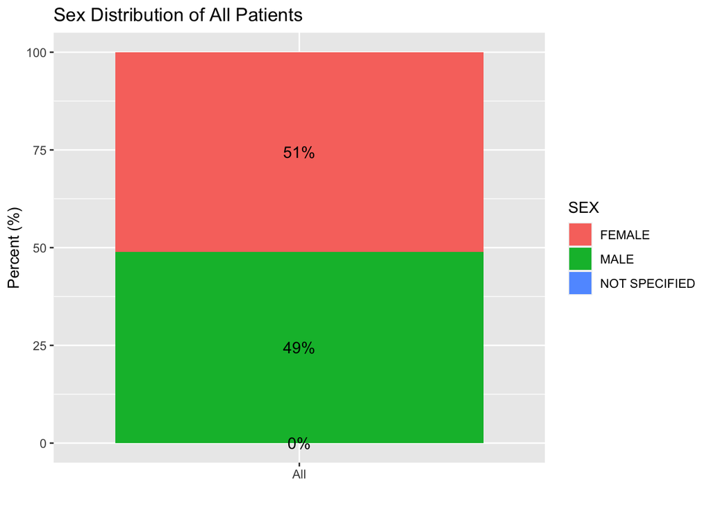

```r
#-----------------------------------------------------------------------------
# Visualise the data

# 1.a. Sex distribution
sex_dist$label = paste0(sprintf("%.0f", sex_dist$Percent), "%")

# stacked bar
ggplot(sex_dist, aes(x = Patients, y = Percent, fill = SEX)) +
  geom_bar(position = "stack", stat='identity') +
  geom_text(aes(label = label), position = position_stack(vjust = 0.5), size = 4) +
  labs(x = "",
       y = "Percent (%)",
      title="Sex Distribution of All Patients")
```

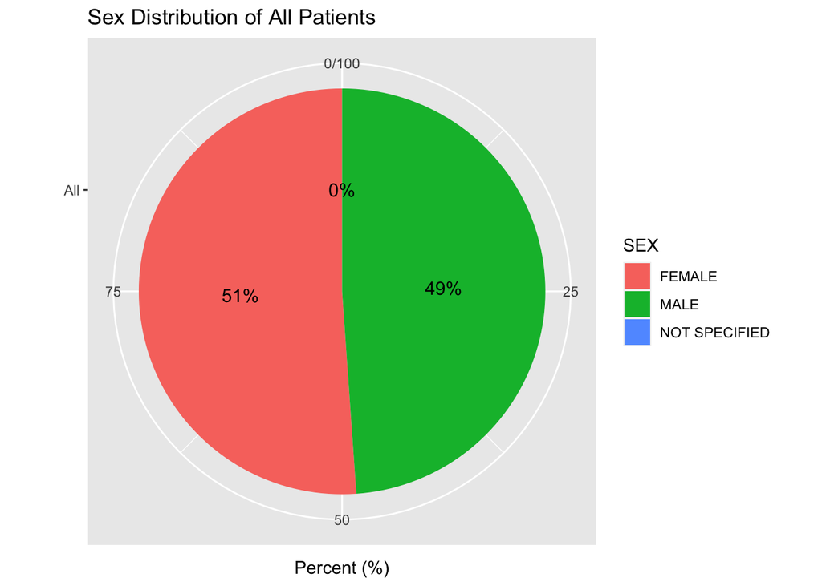

```r
# could also visualise using a pie chart
ggplot(sex_dist, aes(x = Patients, y = Percent, fill = SEX)) +
  geom_bar(width = 1, stat = "identity") +
  coord_polar("y", start=0) +
  geom_text(aes(label = label), position = position_stack(vjust = 0.5), size = 4) +
  labs(x = "",
       y = "Percent (%)",
      title="Sex Distribution of All Patients")
```

We can see that the distribution of sex for this dataset is evenly split with only 2 patients that have not specified their gender.

## b. Prepare a dataset with all lung cancer patients (SITE_ICD10_O2_3CHAR= C34) and their cause of deaths.

This section requires a patient level dataset of those that have had lung cancer. Steps: 1. Find those that have had tumours relating to lung cancer 2. Extract patients in the patient level data that correspond to 1

```r
#=============================================================================
# 1. b. Prepare a dataset with all lung cancer patients (SITE_ICD10_O2_3CHAR= C34) and their cause of deaths.

#-----------------------------------------------------------------------------
# 1. Find those that have had tumours relating to lung cancer

# define our target ICD10 code for lung cancer (C34: Malignant neoplasm of bronchus and lung)
target <- "C34"

# Extract the IDs for patients with lung cancer tumours (There are 167233 patients that have lung cancer)
lung_cancer_patient_ids <- unique(sim_av_tumour$PATIENTID[sim_av_tumour$SITE_ICD10_O2_3CHAR == target])

#-----------------------------------------------------------------------------
# 2. Extract patients in the patient level data that correspond to 1.
lung_cancer_patients <- sim_av_patient[sim_av_patient$PATIENTID %in% lung_cancer_patient_ids,]

# check
head(lung_cancer_patients)
```

```
##        PATIENTID    SEX LINKNUMBER                    ETHNICITY
## 223211  10223872 FEMALE  810223872                WHITE BRITISH
## 225682  10226354   MALE  810226354 C ANY OTHER WHITE BACKGROUND
## 225902  10226574 FEMALE  810226574                         <NA>
## 231875  10232562 FEMALE  810232562                WHITE BRITISH
## 232218  10232905   MALE  810232905                WHITE BRITISH
## 232229  10232916   MALE  810232916                WHITE BRITISH
##        DEATHCAUSECODE_1A DEATHCAUSECODE_1B DEATHCAUSECODE_1C DEATHCAUSECODE_2
## 223211              <NA>              <NA>              <NA>             <NA>
## 225682              <NA>              <NA>              <NA>             <NA>
## 225902          N19,K729              J449              <NA>             K631
## 231875              <NA>              <NA>              <NA>             <NA>
## 232218              <NA>              <NA>              <NA>             <NA>
## 232229              <NA>              <NA>              <NA>             <NA>
##        DEATHCAUSECODE_UNDERLYING DEATHLOCATIONCODE NEWVITALSTATUS
## 223211                       C61              <NA>          Alive
## 225682                      <NA>              <NA>          Alive
## 225902                      J440                 1          Alive
## 231875                      <NA>              <NA>          Alive
## 232218                      <NA>              <NA>          Alive
## 232229                      <NA>              <NA>          Alive
##        VITALSTATUSDATE
## 223211      2019-02-11
## 225682      2019-02-09
## 225902      2019-02-11
## 231875      2019-02-06
## 232218      2019-02-09
## 232229      2019-02-11
```

We now have all lung cancer patients with their id, sex, link number, ethnicity, cause of death, vital status and vital status date.

## c. Calculate the mean survival time in days for the lung cancer patients who were diagnosed in 2013.

*Cohort* The cohort for the survival analysis will be patients that have ever had a lung cancer diagnosis and were diagnosed in 2013.

To calculate the mean survival time, we will conduct a survival analysis. In order to conduct a survival analysis we need to define: 1. *Mean survival*: The average length of time from date of lung cancer diagnosis who are still alive. 2. *Target event*: The event of interest will be death status. 3. *Time origin*: The time at which follow-up time starts is the date of lung cancer diagnosis. 4. *Time scale*: Time will be days from time origin to time of event, and patients will be right censored (for those that are alive).

In order to do survival analysis, we also need to prepare the data a bit further. Key components for survival analysis are (for each subject i): 1. Event time Ti 2. Censoring time Ci 3. Event indicator δi: - 1 if event observed (i.e. Ti≤Ci) - 0 if censored (i.e. Ti>Ci) 4. Observed time Yi=min(Ti,Ci)

The observed times and an event indicator are provided in the lung data. We will create: - time: Survival time in days (Yi) - status: censoring status 0=censored, 1=dead (δi)

Here we will be modeling survival for those that were diagnosed with lung cancer tumours from 2013. We need to therefore: 1. Find the first diagnosis date for lung cancer patients 1. Create status variable from NEWVITALSTATUS as Dead; 1 or censored; 0. 2. Create a time variable that shows the time from diagnosis until status.

```r
#=============================================================================
# 1.c. Calculate the mean survival time in days for the lung cancer patients who were diagnosed in 2013.
#-----------------------------------------------------------------------------

# 1. Find the first diagnosis date for lung cancer patients

# get lung cancer tumours
lung_cancer_tumours <- sim_av_tumour[sim_av_tumour$SITE_ICD10_O2_3CHAR == target, ] # 169,118 rows

# from this tumour data, get the earliest date of diagnosis for each patient
first_diagnosis <- lung_cancer_tumours %>%
  select(PATIENTID, DIAGNOSISDATEBEST) %>%
  group_by(PATIENTID) %>%
  filter(DIAGNOSISDATEBEST == min(DIAGNOSISDATEBEST)) %>%
  distinct()

# check
head(first_diagnosis) # 167333 rows, matches patient numbers.
```

```
## # A tibble: 6 x 2
## # Groups:   PATIENTID [6]
##   PATIENTID DIAGNOSISDATEBEST
##       <int> <date>
## 1  10274980 2016-07-05
## 2  10274987 2017-05-25
## 3  10274990 2017-10-26
## 4  10274994 2017-04-03
## 5  10274999 2017-09-09
## 6  10275001 2016-10-10
```

```r
# merge patient diagnosis data to patient level data by patient id
lung_cancer_patients <- left_join(lung_cancer_patients, first_diagnosis,by="PATIENTID")

# check
head(lung_cancer_patients)
```

```
##   PATIENTID    SEX LINKNUMBER                    ETHNICITY DEATHCAUSECODE_1A
## 1  10223872 FEMALE  810223872                WHITE BRITISH              <NA>
## 2  10226354   MALE  810226354 C ANY OTHER WHITE BACKGROUND              <NA>
## 3  10226574 FEMALE  810226574                         <NA>          N19,K729
## 4  10232562 FEMALE  810232562                WHITE BRITISH              <NA>
## 5  10232905   MALE  810232905                WHITE BRITISH              <NA>
## 6  10232916   MALE  810232916                WHITE BRITISH              <NA>
##   DEATHCAUSECODE_1B DEATHCAUSECODE_1C DEATHCAUSECODE_2
## 1              <NA>              <NA>             <NA>
## 2              <NA>              <NA>             <NA>
## 3              J449              <NA>             K631
## 4              <NA>              <NA>             <NA>
## 5              <NA>              <NA>             <NA>
## 6              <NA>              <NA>             <NA>
##   DEATHCAUSECODE_UNDERLYING DEATHLOCATIONCODE NEWVITALSTATUS VITALSTATUSDATE
## 1                       C61              <NA>          Alive      2019-02-11
## 2                      <NA>              <NA>          Alive      2019-02-09
## 3                      J440                 1          Alive      2019-02-11
## 4                      <NA>              <NA>          Alive      2019-02-06
## 5                      <NA>              <NA>          Alive      2019-02-09
## 6                      <NA>              <NA>          Alive      2019-02-11
##   DIAGNOSISDATEBEST
## 1        2017-02-13
## 2        2016-10-20
## 3        2017-12-05
## 4        2016-09-25
## 5        2017-08-30
## 6        2017-12-14
```

We now create our time variable for survival analysis. This will be shown in days (the time from first diagnosis to status date). We will also create our status variable that flags those that have died as 1 and those that are still alive as 0, as they are right censored.

Date variables:

- DIAGNOSISDATEBEST = diagnosis date
- VITALSTATUSDATE = date of vital status

```r
#-----------------------------------------------------------------------------
# format dates and calculate time from diagnosis to event
lung_cancer_patients <- lung_cancer_patients %>% mutate(
  DIAGNOSISDATEBEST = as.Date(DIAGNOSISDATEBEST, format = "%Y-%m-%d"),
  VITALSTATUSDATE = as.Date(VITALSTATUSDATE, format = "%Y-%m-%d"),
  time = as.numeric(difftime(VITALSTATUSDATE, DIAGNOSISDATEBEST, units = "days")),
  status = ifelse(NEWVITALSTATUS == "Dead",1,0)
)

# check
head(lung_cancer_patients)
```

```
##   PATIENTID    SEX LINKNUMBER                    ETHNICITY DEATHCAUSECODE_1A
## 1  10223872 FEMALE  810223872                WHITE BRITISH              <NA>
## 2  10226354   MALE  810226354 C ANY OTHER WHITE BACKGROUND              <NA>
## 3  10226574 FEMALE  810226574                         <NA>          N19,K729
## 4  10232562 FEMALE  810232562                WHITE BRITISH              <NA>
## 5  10232905   MALE  810232905                WHITE BRITISH              <NA>
## 6  10232916   MALE  810232916                WHITE BRITISH              <NA>
##   DEATHCAUSECODE_1B DEATHCAUSECODE_1C DEATHCAUSECODE_2
## 1              <NA>              <NA>             <NA>
## 2              <NA>              <NA>             <NA>
## 3              J449              <NA>             K631
## 4              <NA>              <NA>             <NA>
## 5              <NA>              <NA>             <NA>
## 6              <NA>              <NA>             <NA>
##   DEATHCAUSECODE_UNDERLYING DEATHLOCATIONCODE NEWVITALSTATUS VITALSTATUSDATE
## 1                       C61              <NA>          Alive      2019-02-11
## 2                      <NA>              <NA>          Alive      2019-02-09
## 3                      J440                 1          Alive      2019-02-11
## 4                      <NA>              <NA>          Alive      2019-02-06
## 5                      <NA>              <NA>          Alive      2019-02-09
## 6                      <NA>              <NA>          Alive      2019-02-11
##   DIAGNOSISDATEBEST time status
## 1        2017-02-13  728      0
## 2        2016-10-20  842      0
## 3        2017-12-05  433      0
## 4        2016-09-25  864      0
## 5        2017-08-30  528      0
## 6        2017-12-14  424      0
```

Everything looks great! Now lets subset patients that were diagnosed in 2013.

```r
#-----------------------------------------------------------------------------
# filter patients that were diagnosed in 2013 only as per condition. Of all the lung cancer patients, we only want those that were diagnosed in 2013.
lung_cancer_patients_2013 <- lung_cancer_patients %>% filter(DIAGNOSISDATEBEST >= "2013-01-01" & DIAGNOSISDATEBEST <= "2013-12-31") # N = 35210

# See how many have died
table(lung_cancer_patients_2013$NEWVITALSTATUS)
```

```
##
##        Alive         Dead Exit Posting
##         7792        27403           15
```

```r
# Alive = 7792
# Died = 27403
# Exit posting = 15

# Examine vital status.
lung_cancer_deaths <- lung_cancer_patients_2013 %>%
  count(NEWVITALSTATUS) %>%
  # count creates a column called 'n'
  mutate(Percent = round(n / sum(n) * 100,2),
         Patients = "All")
# preview
lung_cancer_deaths
```

```
##   NEWVITALSTATUS     n Percent Patients
## 1          Alive  7792   22.13      All
## 2           Dead 27403   77.83      All
## 3   Exit Posting    15    0.04      All
```

[figure not shown]

```r
# add label for plot
lung_cancer_deaths$label = paste0(sprintf("%.0f", lung_cancer_deaths$Percent), "%")

# create stacked bar chart
ggplot(lung_cancer_deaths, aes(x = Patients, y = Percent, fill = NEWVITALSTATUS)) +
  geom_bar(position = "stack", stat='identity') +
  geom_text(aes(label = label), position = position_stack(vjust = 0.5), size = 4) +
  labs(x = "",
       y = "Percent (%)",
      title="Sex Distribution of All Patients")
```

We can see that 78% of patients that were diagnosed with lung cancer have died, with 22% alive or exit posting.

*Model survival*

First we will calculate the survival probability for lung cancer patients. This shows the probability that a patient survives from the time origin (lung cancer diagnosis) to the event time.

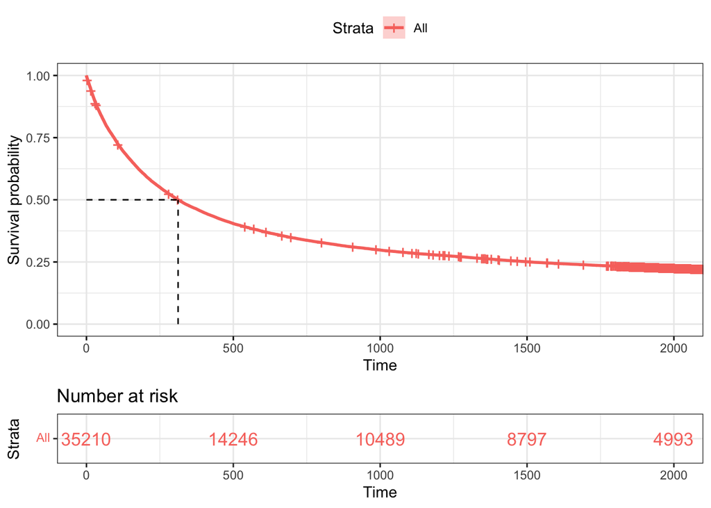

```r
#-----------------------------------------------------------------------------
# Survival analysis

# Kaplan-Meier estimate can be obtained as numbers by using survfit
om.fit <- survfit(Surv(time, status) ~ 1, data = lung_cancer_patients_2013)

# Change color, linetype by strata, risk.table color by strata
ggsurvplot(om.fit,
          risk.table = TRUE, # Add risk table
          risk.table.col = "strata",
          linetype = "strata",
          surv.median.line = "hv", # Specify median survival
          ggtheme = theme_bw() # Change ggplot2 theme
)
```

We can examine the cumulative events.

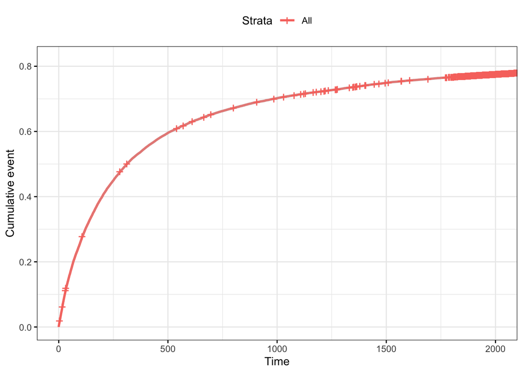

```r
ggsurvplot(om.fit,
          conf.int = TRUE,
          risk.table.col = "strata",
          ggtheme = theme_bw(), # Change ggplot2 theme
          fun = "event")
```

```r
# calculate mean, median survival time
print(om.fit, print.rmean=TRUE)
```

```
## Call: survfit(formula = Surv(time, status) ~ 1, data = lung_cancer_patients_2013)
##
##          n     events     *rmean *se(rmean)     median    0.95LCL    0.95UCL
##   35210.00   27403.00     772.55       4.61     312.00     305.00     320.00
##     * restricted mean with upper limit =  2231
```

Survival analysis shows that the median survival for 50% of patients is 312 days.

```r
#The mean survival time in lung cancer patients followed-up to 5 years
survival:::survmean(om.fit, rmean=5*365) [[1]]["*rmean"]
```

```
##   *rmean
## 682.3293
```

The restricted mean survival time for a 5-year period is 682 days (1.8 years).

# 2. Visualising Data

Using the UK synthetic cancer registry data (Simulacrum):

1. Visualise the proportion of all ethnic groups among non-British male patients. You can find ethnic information of patients in the data dictionary provided in the simulacrum dataset.
2. Explore the data to find an interesting or insightful aspect that you can then communicate visually. Be creative!

## a. Visualise the proportion of all ethnic groups among non-British male patients. You can find ethnic information of patients in the data dictionary provided in the simulacrum dataset.

```r
# Calculate the n and percent of patients by gender
eth_dist <- sim_av_patient %>%
  count(ETHNICITY) %>%
  # count creates a column called 'n'
  mutate(Percent = round(n / sum(n) * 100,2),
         Patients = "All")

# show results
eth_dist[order(eth_dist$Percent, decreasing =T), ]
```

```
##                        ETHNICITY       n Percent Patients
## 19                 WHITE BRITISH 1764883   80.20      All
## 22                          <NA>  171927    7.81      All
## 7   C ANY OTHER WHITE BACKGROUND   66526    3.02      All
## 14                    NOT STATED   62615    2.85      All
## 16      S ANY OTHER ETHNIC GROUP   19892    0.90      All
## 20                   WHITE IRISH   18597    0.85      All
## 21                   X NOT KNOWN   16688    0.76      All
## 3                   ASIAN INDIAN   16285    0.74      All
## 6                BLACK CARIBBEAN   13741    0.62      All
## 4                ASIAN PAKISTANI    9929    0.45      All
## 5                  BLACK AFRICAN    9658    0.44      All
## 11  L ANY OTHER ASIAN BACKGROUND    9508    0.43      All
## 15  P ANY OTHER BLACK BACKGROUND    5130    0.23      All
## 8                        CHINESE    4004    0.18      All
## 10  G ANY OTHER MIXED BACKGROUND    3116    0.14      All
## 2              ASIAN BANGLADESHI    2863    0.13      All
## 18     WHITE AND BLACK CARIBBEAN    1932    0.09      All
## 12         MIXED WHITE AND ASIAN    1440    0.07      All
## 13 MIXED WHITE AND BLACK AFRICAN     996    0.05      All
## 17                         WHITE     847    0.04      All
## 1                        8 OTHER      47    0.00      All
## 9                        English       2    0.00      All
```

Before sub-setting the data, we can see that the majority of patients are white British. This is expected as the data is simulated from real cancer data in the UK. This however, is an important factor to consider when conducting an analysis as this may show potential bias towards certain ethnicities.

```r
# Calculate the n and percent of patients by gender
bysex <- sim_av_patient %>%
  group_by(ETHNICITY, SEX) %>%
  count(ETHNICITY, SEX)

bysex <- bysex %>% group_by(ETHNICITY) %>% mutate(Percent = (n/sum(n) * 100), Patients = "All")
bysex[order(bysex$n, decreasing =T), ]
```

```
## # A tibble: 45 x 5
## # Groups:   ETHNICITY [22]
##    ETHNICITY                    SEX         n Percent Patients
##    <fct>                        <fct>   <int>   <dbl> <chr>
##  1 WHITE BRITISH                FEMALE 886419    50.2 All
##  2 WHITE BRITISH                MALE   878464    49.8 All
##  3 <NA>                         FEMALE  99818    58.1 All
##  4 <NA>                         MALE    72109    41.9 All
##  5 C ANY OTHER WHITE BACKGROUND FEMALE  37699    56.7 All
##  6 NOT STATED                   MALE    32289    51.6 All
##  7 NOT STATED                   FEMALE  30326    48.4 All
##  8 C ANY OTHER WHITE BACKGROUND MALE    28827    43.3 All
##  9 S ANY OTHER ETHNIC GROUP     FEMALE  10737    54.0 All
## 10 WHITE IRISH                  MALE     9841    52.9 All
## # … with 35 more rows
```

We can see that most ethnicities are evenly split between genders. With the exception on white and black Caribbean’s, mixed white and Asians, Chinese, and others showing slighter higher proportion of females.

```r
# We are interested in examining non-British males patients. The only identifier of British patients is via the ethnicity "WHITE BRITISH" and "English". Patients that are exclusively "WHITE" could cover those from other European regions

exclusions <- c("WHITE BRITISH", "English")

# we create a not in for our exclusions filter
`%notin%` <- Negate(`%in%`)

# subset data
non_british_males <- sim_av_patient %>% filter(SEX == 'MALE' & ETHNICITY %notin% exclusions)

# Show patients that were non-british
cat("Out of the", length(unique(sim_av_patient$PATIENTID)), "patients, there are", length(unique(non_british_males$PATIENTID)), "that are non-british males.")
```

```
## Out of the 2200626 patients, there are 197284 that are non-british males.
```

```r
# check distribution of ethnicities
table(non_british_males$ETHNICITY)
```

```
##
##                       8 OTHER             ASIAN BANGLADESHI
##                            14                          1299
##                  ASIAN INDIAN               ASIAN PAKISTANI
##                          7241                          4447
##                 BLACK AFRICAN               BLACK CARIBBEAN
##                          4645                          7169
##  C ANY OTHER WHITE BACKGROUND                       CHINESE
##                         28827                          1531
##                       English  G ANY OTHER MIXED BACKGROUND
##                             0                          1260
##  L ANY OTHER ASIAN BACKGROUND         MIXED WHITE AND ASIAN
##                          4177                           557
## MIXED WHITE AND BLACK AFRICAN                    NOT STATED
##                           418                         32289
##  P ANY OTHER BLACK BACKGROUND      S ANY OTHER ETHNIC GROUP
##                          2680                          9155
##                         WHITE     WHITE AND BLACK CARIBBEAN
##                           391                           803
##                 WHITE BRITISH                   WHITE IRISH
##                             0                          9841
##                   X NOT KNOWN
##                          8431
```

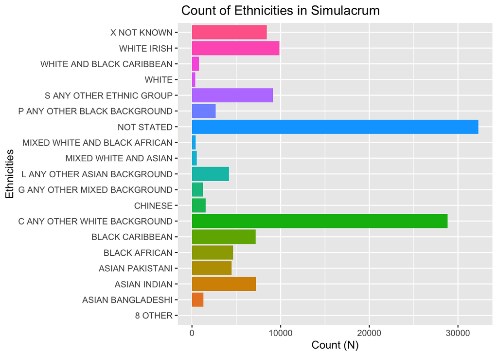

```r
# bar chart
p <- ggplot(data = subset(non_british_males, !is.na(non_british_males$ETHNICITY)), aes(x = ETHNICITY, fill=ETHNICITY)) +
  geom_bar() + labs(x = "Ethnicities", y = "Count (N)", title = " Count of Ethnicities in Simulacrum") + scale_fill_discrete(name = "Ethnicity") + theme(legend.position = "none")

p + coord_flip()
```

There are a lot of groups for ethnicity. We can group a lot of them together to get five major groups.

```r
# White, black, asian, mixed, ethnic
white <- c("C ANY OTHER WHITE BACKGROUND", "WHITE BRITISH", "WHITE", "WHITE IRISH", "English")
black <- c("BLACK AFRICAN", "BLACK CARIBBEAN", "P ANY OTHER BLACK BACKGROUND")
mixed <- c("G ANY OTHER MIXED BACKGROUND", "MIXED WHITE AND BLACK AFRICAN", "MIXED WHITE AND ASIAN", "WHITE AND BLACK CARIBBEAN")
asian <- c("ASIAN PAKISTANI", "ASIAN BANGLADESHI", "L ANY OTHER ASIAN BACKGROUND", "ASIAN INDIAN", "CHINESE")
other <- c("8 OTHER", "S ANY OTHER ETHNIC GROUP")
notKnown <- c("NOT STATED", "X NOT KNOWN")


# create grouped variable
non_british_males$ethnicity_grouped <- NA
non_british_males$ethnicity_grouped[non_british_males$ETHNICITY %in% white] <- "WHITE"
non_british_males$ethnicity_grouped[non_british_males$ETHNICITY %in% black] <- "BLACK"
non_british_males$ethnicity_grouped[non_british_males$ETHNICITY %in% mixed] <- "MIXED"
non_british_males$ethnicity_grouped[non_british_males$ETHNICITY %in% asian] <- "ASIAN"
non_british_males$ethnicity_grouped[non_british_males$ETHNICITY %in% other] <- "OTHER"
non_british_males$ethnicity_grouped[non_british_males$ETHNICITY %in% notKnown] <- NA
non_british_males$ethnicity_grouped[is.na(non_british_males$ETHNICITY)] <- NA
```

View grouped ethnicities.

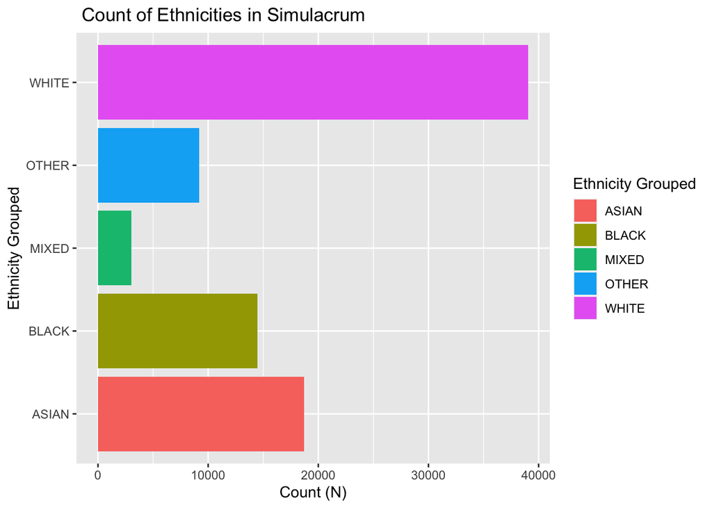

```r
#-----------------------------------------------------------------------------
# bar chart
ggplot(data = subset(non_british_males,!is.na(non_british_males$ethnicity_grouped)), aes(x = ethnicity_grouped, fill=ethnicity_grouped)) +
  geom_bar() + coord_flip() + labs(x = "Ethnicity Grouped", y = "Count (N)", title = " Count of Ethnicities in Simulacrum") + scale_fill_discrete(name = "Ethnicity Grouped")
```

White is still the most prominent group among non-British males, followed by Asian, Black, other and mixed. We can explore within each group.

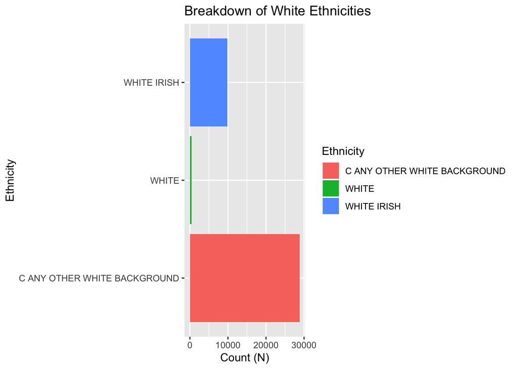

```r
# Split by groups

# white
non_british_males %>% filter(!is.na(non_british_males$ethnicity_grouped) & non_british_males$ETHNICITY %in% white) %>%
ggplot(aes(x = ETHNICITY, fill=ETHNICITY)) +
  geom_bar() + coord_flip() + labs(x = "Ethnicity", y = "Count (N)", title = "Breakdown of White Ethnicities") + scale_fill_discrete(name = "Ethnicity")
```

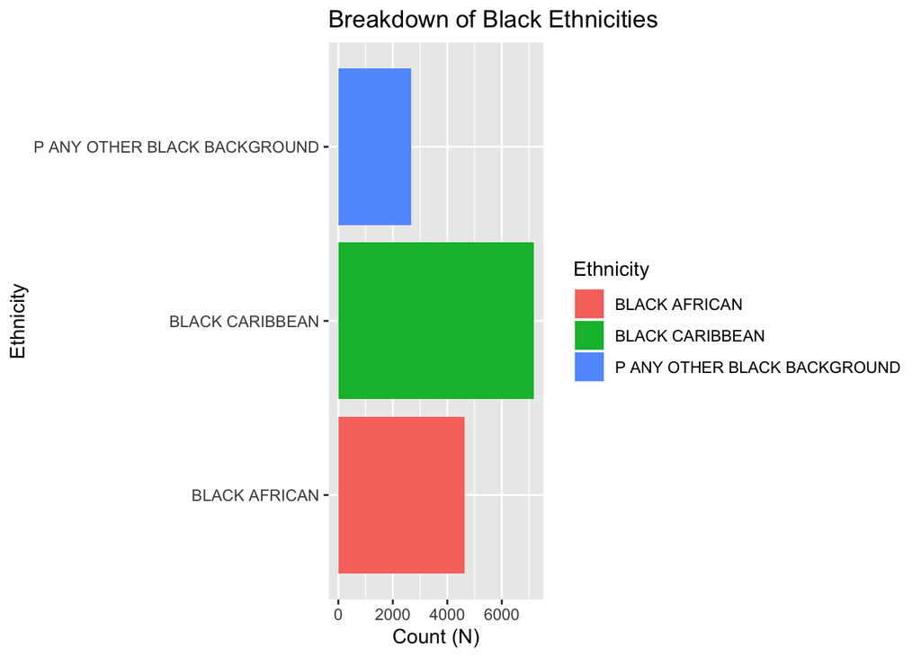

```r
# black
non_british_males %>% filter(!is.na(non_british_males$ethnicity_grouped) & non_british_males$ETHNICITY %in% black) %>%
ggplot(aes(x = ETHNICITY, fill=ETHNICITY)) +
  geom_bar() + coord_flip() + labs(x = "Ethnicity", y = "Count (N)", title = "Breakdown of Black Ethnicities") + scale_fill_discrete(name = "Ethnicity")
```

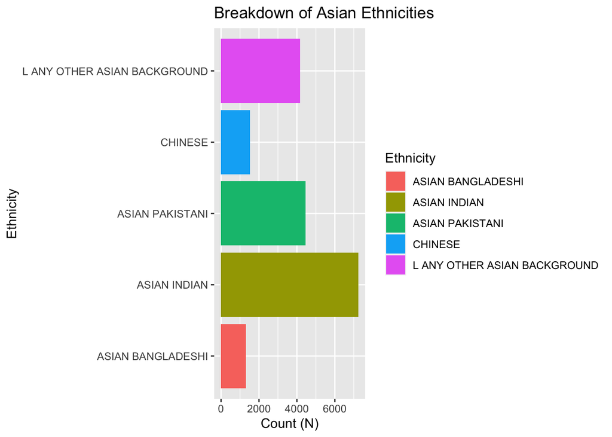

```r
# asian
non_british_males %>% filter(!is.na(non_british_males$ethnicity_grouped) & non_british_males$ETHNICITY %in% asian) %>%
ggplot(aes(x = ETHNICITY, fill=ETHNICITY)) +
  geom_bar() + coord_flip() + labs(x = "Ethnicity", y = "Count (N)", title = "Breakdown of Asian Ethnicities") + scale_fill_discrete(name = "Ethnicity")
```

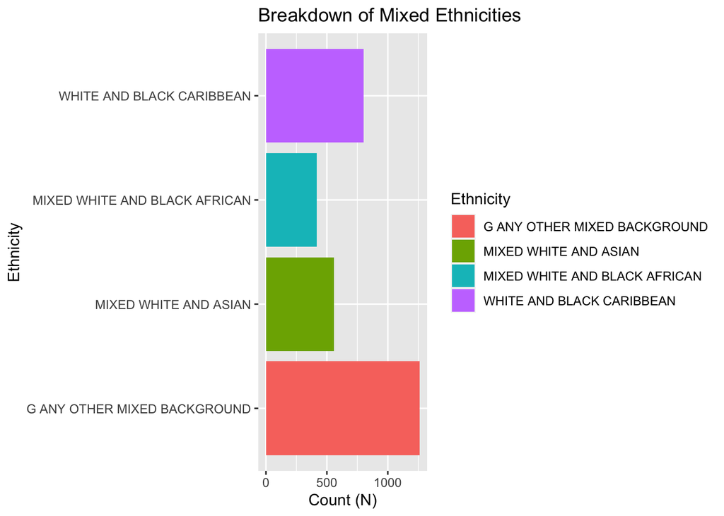

```r
# mixed
non_british_males %>% filter(!is.na(non_british_males$ethnicity_grouped) & non_british_males$ETHNICITY %in% mixed) %>%
ggplot(aes(x = ETHNICITY, fill=ETHNICITY)) +
  geom_bar() + coord_flip() + labs(x = "Ethnicity", y = "Count (N)", title = "Breakdown of Mixed Ethnicities") + scale_fill_discrete(name = "Ethnicity")
```

Asian indians make up most of the Asian category and black carribeans make up most of the black ethnic group. For thsoe that are mixed, other was the most prominent, followed by black and white caribbean.

## b. Explore the data to find an interesting or insightful aspect that you can then communicate visually. Be creative!

Here we will examine the ethnicity for our lung cancer patients that were diagnosed in 2013. Let’s first apply the same grouping technique as above.

```r
#=============================================================================
# 2.b. Explore: Group ethnicities

# White, black, asian, mixed, ethnic
white <- c("C ANY OTHER WHITE BACKGROUND", "WHITE BRITISH", "WHITE", "WHITE IRISH", "English")
black <- c("BLACK AFRICAN", "BLACK CARIBBEAN", "P ANY OTHER BLACK BACKGROUND")
mixed <- c("G ANY OTHER MIXED BACKGROUND", "MIXED WHITE AND BLACK AFRICAN", "MIXED WHITE AND ASIAN", "WHITE AND BLACK CARIBBEAN")
asian <- c("ASIAN PAKISTANI", "ASIAN BANGLADESHI", "L ANY OTHER ASIAN BACKGROUND", "ASIAN INDIAN", "CHINESE")
other <- c("8 OTHER", "S ANY OTHER ETHNIC GROUP")
notKnown <- c("NOT STATED", "X NOT KNOWN")


# create grouped variable
lung_cancer_patients_2013$ethnicity_grouped <- NA
lung_cancer_patients_2013$ethnicity_grouped[lung_cancer_patients_2013$ETHNICITY %in% white] <- "WHITE"
lung_cancer_patients_2013$ethnicity_grouped[lung_cancer_patients_2013$ETHNICITY %in% black] <- "BLACK"
lung_cancer_patients_2013$ethnicity_grouped[lung_cancer_patients_2013$ETHNICITY %in% mixed] <- "MIXED"
lung_cancer_patients_2013$ethnicity_grouped[lung_cancer_patients_2013$ETHNICITY %in% asian] <- "ASIAN"
lung_cancer_patients_2013$ethnicity_grouped[lung_cancer_patients_2013$ETHNICITY %in% other] <- "OTHER"
lung_cancer_patients_2013$ethnicity_grouped[lung_cancer_patients_2013$ETHNICITY %in% notKnown] <- NA
lung_cancer_patients_2013$ethnicity_grouped[is.na(lung_cancer_patients_2013$ETHNICITY)] <- NA
```

Count the ethnicities amongst lung cancer patients diagnosed in 2013.

```r
lung_cancer_order <-
  lung_cancer_patients_2013 %>%
  count(ethnicity_grouped) %>%
  mutate(Percent = round(n / sum(n) * 100,2),
         Patients = "All")

# add label for plot
lung_cancer_order[order(lung_cancer_order$Percent, decreasing = T),]
```

```
##   ethnicity_grouped     n Percent Patients
## 5             WHITE 32142   91.29      All
## 6              <NA>  1705    4.84      All
## 1             ASIAN   627    1.78      All
## 2             BLACK   354    1.01      All
## 4             OTHER   290    0.82      All
## 3             MIXED    92    0.26      All
```

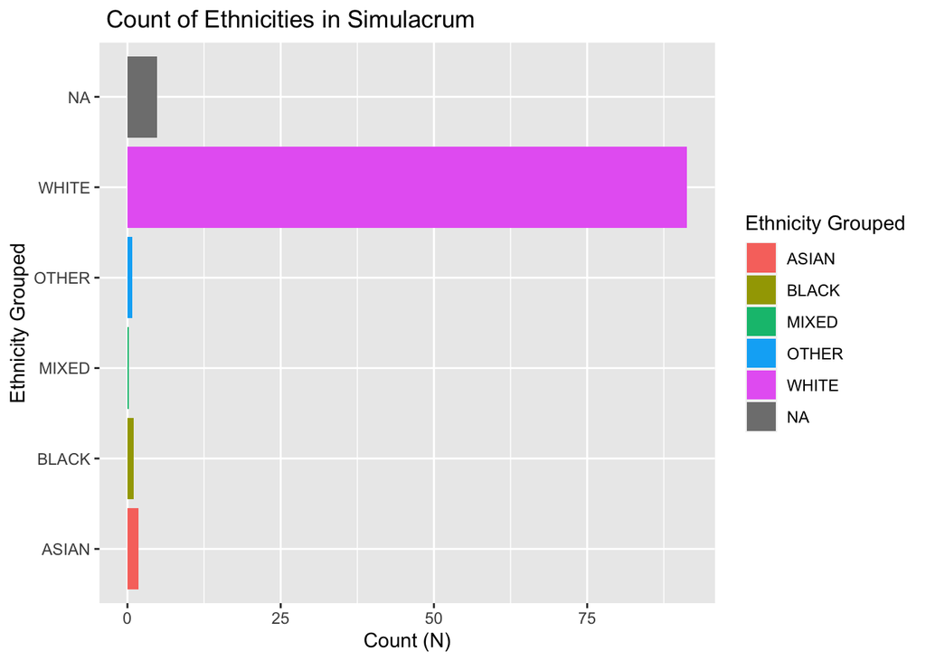

```r
# create stacked bar chart
ggplot(lung_cancer_order, aes(x = ethnicity_grouped, y = Percent, fill = ethnicity_grouped)) +
  geom_bar(stat='identity') + coord_flip() + labs(x = "Ethnicity Grouped", y = "Count (N)", title = " Count of Ethnicities in Simulacrum") + scale_fill_discrete(name = "Ethnicity Grouped")
```

Majority of the patients that were diagnosed with lung cancer in 2013 were white, followed by Asian, Black, other and mixed.

We can also examine of these patients, what was the gender split by ethnicity.

```r
# Calculate the n of patients
bysex <- lung_cancer_patients_2013 %>%
  group_by(ethnicity_grouped, SEX) %>%
  count(ethnicity_grouped, SEX)

# Calculate the percent by group
bysex <- bysex %>% group_by(ethnicity_grouped) %>% mutate(Percent = (n/sum(n) * 100), Patients = "All")
bysex[order(bysex$n, decreasing =T), ]
```

```
## # A tibble: 12 x 5
## # Groups:   ethnicity_grouped [6]
##    ethnicity_grouped SEX        n Percent Patients
##    <chr>             <fct>  <int>   <dbl> <chr>
##  1 WHITE             MALE   16749    52.1 All
##  2 WHITE             FEMALE 15393    47.9 All
##  3 <NA>              MALE     911    53.4 All
##  4 <NA>              FEMALE   794    46.6 All
##  5 ASIAN             MALE     426    67.9 All
##  6 BLACK             MALE     224    63.3 All
##  7 ASIAN             FEMALE   201    32.1 All
##  8 OTHER             MALE     175    60.3 All
##  9 BLACK             FEMALE   130    36.7 All
## 10 OTHER             FEMALE   115    39.7 All
## 11 MIXED             MALE      53    57.6 All
## 12 MIXED             FEMALE    39    42.4 All
```

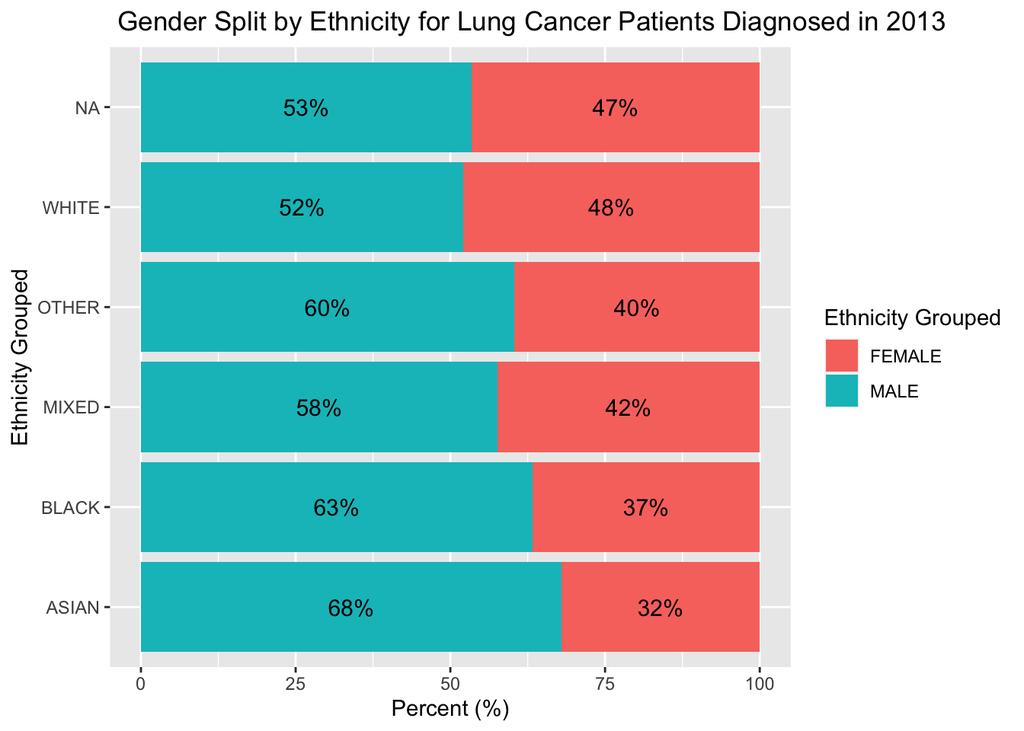

```r
# add labels for plot
bysex$label = paste0(sprintf("%.0f", bysex$Percent), "%")

# create plot
ggplot(bysex, aes(x = ethnicity_grouped, y = Percent, fill = SEX)) +
  geom_bar(position = "stack", stat='identity') +
  geom_text(aes(label = label), position = position_stack(vjust = 0.5), size = 4) + coord_flip() + labs(x = "Ethnicity Grouped", y = "Percent (%)", title = " Gender Split by Ethnicity for Lung Cancer Patients Diagnosed in 2013") + scale_fill_discrete(name = "Ethnicity Grouped")
```

```r
# Calculate the n and percent of patients by gender
bysex <- lung_cancer_patients_2013 %>%
  group_by(ETHNICITY, SEX) %>%
  count(ETHNICITY, SEX)

bysex <- bysex %>% group_by(ETHNICITY) %>% mutate(Percent = (n/sum(n) * 100), Patients = "All")
bysex[order(bysex$n, decreasing =T), ]
```

```
## # A tibble: 40 x 5
## # Groups:   ETHNICITY [20]
##    ETHNICITY                    SEX        n Percent Patients
##    <fct>                        <fct>  <int>   <dbl> <chr>
##  1 WHITE BRITISH                MALE   16022    52.0 All
##  2 WHITE BRITISH                FEMALE 14765    48.0 All
##  3 C ANY OTHER WHITE BACKGROUND MALE     537    55.6 All
##  4 <NA>                         MALE     436    55.8 All
##  5 C ANY OTHER WHITE BACKGROUND FEMALE   428    44.4 All
##  6 NOT STATED                   MALE     385    50.4 All
##  7 NOT STATED                   FEMALE   379    49.6 All
##  8 <NA>                         FEMALE   346    44.2 All
##  9 WHITE IRISH                  FEMALE   191    50.7 All
## 10 WHITE IRISH                  MALE     186    49.3 All
## # … with 30 more rows
```

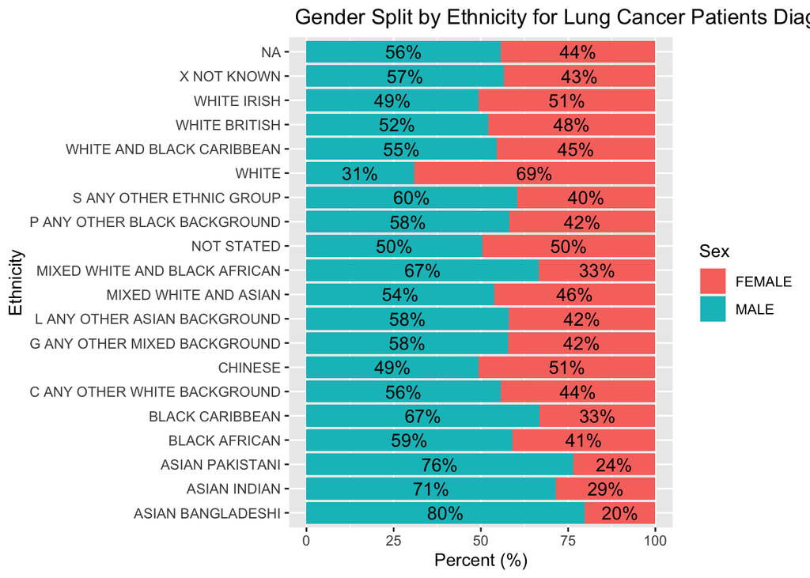

```r
# 1.a. Sex distribution
bysex$label = paste0(sprintf("%.0f", bysex$Percent), "%")

ggplot(bysex, aes(x = ETHNICITY, y = Percent, fill = SEX)) +
  geom_bar(position = "stack", stat='identity') +
  geom_text(aes(label = label), position = position_stack(vjust = 0.5), size = 4) + coord_flip() + labs(x = "Ethnicity", y = "Percent (%)", title = " Gender Split by Ethnicity for Lung Cancer Patients Diagnosed in 2013") + scale_fill_discrete(name = "Sex")
```

*Data used artificial data from the Simulacrum, a synthetic dataset developed by Health Data Insight CiC derived from anonymous cancer data provided by the National Cancer Registration and Analysis Service, which is part of Public Health England*